Identificando Componentes Populistas no Discurso de Parlamentares

# A Definição de Populismo

Certamente, líderes populistas são o mecanismo mais evidente pelo qual democracias com *guardrails* frágeis da democracia sofrem reversões autoritárias. A presença desses atores políticos reduzem, em média, a qualidade da democracia, os *checks and balances* do regime, direitos políticos e liberdades civis e de imprensa (Kyle and Mounk 2018). Assim, seja por realizarem autogolpe ou procarem reações adversas que impulsam interverções militares, a presença desses atores políticos deixam as democracias sob risco.

Mas se populistas são uma ameaça, como podemos identificá-los? Em termos comportamentais, Levitsky e Ziblat (2018) definiram 4 indicadores de alerta para verificarmos se um líder possui perfil autoritário. São eles:

- Rejeição às regras democráticas
- Negar a legitimidade da oposição
- Tolerar ou encorajar a violência política
- Ser suscetível a repressão de direitos civis ou de mídia

Segundo os autores, a presença de qualquer um desses traços comportamentais deve ser indicativo de alerta. Contudo, se por lado os indicadores parecem produzir poucos falsos positivos – ou seja, a classificação, como autoritário, de um político que não o é – por outro abre margem para algum número de falsos negativos – a classificação, como não autoritário, de um político que o é. Em grande medida, comportamentos estão associados a capacidade de ação dos atores políticos, e, portanto, é necessário observar características atitudinais, mesmo que elas envolvam conteúdos mentais inacessíveis na pesquisa, para produzir uma definição que dissocie intenções e condições.

No que diz respeito ao conteúdo ideológico de populistas, a literatura apresenta alguma diversidade de descrições, porém com muitos pontos de convergência. Parte dos trabalhos, baseados nos casos da Europa Ocidental, apontam que esses atores políticos concatenam um conjunto fundamental de princípios definidos por: i) identitarismo; ii) anti-pluralismo e iii) anti-globalismo (Betz 1993; Betz and Johnson 2016). Nesse paradigma, o populismo surge e se fortalece como um programa político em prol da identidade nacional – um dos pilares da constituição do Estado moderno – que perdeu espaço num mundo globalizado. Fiéis a democracia e com base numa ‘política do ressentimento’, populistas defendem a volta dos bons tempos, no qual a economia e a cultura estavam sob o controle da nação, sem a influência de imigrantes ou da *troika*.

Outro grupo de autores define populismo como a conjugação de atitudes iliberais, frequentemente ligadas a restrição de liberdades sexuais – como intolerância a divórcio, homossexuais e descriminalização do aborto – e a desconfiança nas elites e nas instituições políticas (Norris and others 2005; Alexander and Welzel 2017). De acordo a narrativa produzida por essa interpretação, populistas se utilizam da rivalidade com direitos de minorias como espantalho para difundir a ideia de que, para combater uma elite que concentra privilégios, é necessário uma conexão orgânica entre governo e soberania popular.

Por fim, é possível identificar um terceiro segmento da literatura que ressalta o nativismo como fator primordial do populismo. Segundo essa premissa, países são habitados pelo ‘verdadeiro povo’ e por ‘aliens’, que parasitam a nação e ocupam o lugar de elite corrupta no poder (Mudde 2010, 2017). Nessa versão, que busca incorporar aspectos mais universais desses atores políticos, a moralidade é tomada como a ponta de lança de suas campanhas, uma vez que a nação é definida a partir de uma clivagem de dois grupos homogêneos que se distinguem como bem e mal.

A adequabilidade de cada uma das definições varia de contexto e de época, porém a versão endossada por Cas Mudde parece funcionar melhor como um *travel concept*, uma vez que é utilizada para caracterizar líderes por todo o globo. Uma das formas de operacionalização da definição foi implementada por Kyle e Gultchin (2018) na construção da base de dados *Populists in Power: 1990–2018*, composta por dados de 46 líderes populistas que ocuparam o cargo de chefes do executivo em 33 países. Para isso, as autoras partiram de duas premissas:

- O verdadeiro povo de um país está submetido a um conflito contra as elites e os intrusos que a ocupam
- Nada deve limitar a vontade do povo

Apesar das premissas compartilharem o núcleo fundamental da narrativa descrita por Cas Mudde, as autoras argumentam que o conflito entre ‘verdadeiro povo’ e ‘aliens’ não se dá apenas em termos da clivagem produzida pelo nativismo. De acordo com Kyle e Gultchin (2018), há pelo menos 3 grandes tipos de populismo:

* **Cultural populism** claims that the true people are the native members of the nation-state, and outsiders can include immigrants, criminals, ethnic and religious minorities, and cosmopolitan elites. Cultural populism tends to emphasise religious traditionalism, law and order, sovereignty, and painting migrants as enemies.**

* **Socio-economic** populism claims that the true people are honest, hard-working members of the working class, and outsiders can include big business, capital owners and actors perceived as propping up an international capitalist system.**

* **Anti-establishment** populism paints the true people as hard-working victims of a state run by special interests and outsiders as political elites. Although all forms of populism rail against political elites, anti-establishment populism distinguishes itself by focusing on establishment elites as the primary enemy of the people and does not sow as many intra-society divisions.**

## A Primeira Tentativa de Operacionalização das Hipóteses e seu Fracasso

# Operacionalizando a Definição

Recentemente, a vitória de Jair Bolsonaro para a corrida presidencial intensificou o debate sobre o fenômeno do populismo no Brasil. Ao longo de sua trajetória política, Bolsonaro tem imputado aos ativistas dos direitos humanos e minorias e partidos ou movimentos à esquerda do espectro ideológico o papel de desvirtuar a família, as tradições e as instituições políticas, na medida em que estabeleceram a hegemonia do ‘politicamente correto’ e sustentaram grandes esquemas de corrupção (Hunter and Power 2019).

No que diz respeito a literatura que estabelece classificações sistemáticas de lideranças, Kyle e Mounk (2018) destacam o presidente Jair Bolsonaro como uma antítese populista dos ideais de Hugo Chavez. Além disso, em palestra na Fundação Getúlio Vargas (FGV), Levitsky, baseado nos 4 indicadores para perfil autoritário que estabeleceu no trabalho em coautoria com Ziblat (2018), sugeriu que a eleição de Bolsonaro, um político autoritário, representava risco à democracia.

Dada a convergência da literatura para apontar Bolsonaro como um caso típico de político populista de sucesso, a primeira tetativa de operacionalização consistiu em tomá-lo como elemento de referência para classificação de parlamentares populistas. Nessa abordagem, maior similaridade com Bolsonaro implica maior probabilidade de identificação com populismo.

# Abordagem Empírica

Como forma de verificação e análise do sistema de classificação que propomos, tomamos os discursos dos parlamentares como indicativo das suas atitudes políticas. Nessa seção, apresentamos os resultados de dois modelos de análise automatizada de conteúdo, realizadas a partir de amostras retiradas de um total de `98307` discursos coletados da Plataforma Dados Abertos da Câmara, realizados por Deputados Federais e Estaduais nas legislaturas 52ª[^1] – 1999 à 2002 – 53ª – 2003 à 2006 –, 54ª – 2007 à 2010 –, 55ª – 2011 à 2014 – e 56ª – 2014 à 2018.

O primeiro modelo que utilizamos foi o *Wordfish*, proposto por Slapin e Proksch (2008). Trata-se de um algoritmo de classificação não supervisionado que estima o posicionamento político latente de discursos de políticos a partir de modelo *naïve Bayes* com distribuição *Poisson*. A partir da variação da frequência relativa do uso de termos, é possível identificar quais grupos de parlamentares apresentam similaridade semântica.

O segundo modelo, como segundo teste para verificar similaridade entre os grupos, utilizamos a análise de correspondência tomando os termos utilizados nos discursos de cada um dos grupos. A técnica envolve a contabilização da frequência do uso de cada uma dos termos mencionados nos discursos e o cálculo da probabilidade de cada um dos grupos mencionar cada um dos termos. Com isso, podemos inferir maior similaridade entre grupos a partir da maior compatibilidade de probabilidade no uso de termos.

Nas análises buscamos comparar dois grupos fundamentais de parlamentares: Parlamentares das Forças de Segurança – ou seja, Candidatos das Forças de Segurança (CFS) que foram eleitos – e membros da família Bolsonaro – Jair e Eduardo Bolsonaro, o qual compõem o caso mais popular de parlamentares de retórica autoritária (Cioccari and Persichetti 2018; Penteado and Lerner 2018) e constituem nossa categoria de referência. Utilizamos os discursos da família Bolsonaro como categoria de referência para avaliar a qualidade do critério de classificação, que esperamos que delimite políticos cuja retória é composta por elementos populistas.

*Wordfish* e a Análise de Correspondência integram um grupo de técnicas chamadas de *unsupervised learning*, as quais, apesar de bastante eficientes, frequentemente produzem classificações baseadas em dimensões difícies de serem traduzidas para critérios analíticos objetivos e coerentes. Com isso, identificar a ideologia latente nos discursos de parlamentares com base no total dos seus discursos, além de possuir custo computacional significativo, possui como efeito produzir resultados sobre os quais possuímos muito pouca compreensão.

Além disso, a Família Bolsonaro, concatena um grande conjunto de características, algumas delas associadas a componentes ideológicos autoritários e outras, idiossincrasias da sua personalidade. Por isso, é importanto tomá-la como categoria de referência em dimensões específicas, nas quais esperamos que os componentes populistas da sua atitude manifestem-se com mais proeminência.

Como estratégia de redução de complexidade e maior generalibilidade das compartações, nos apoiamos na literatura sobre o tema para definição de tópicos que apresentam maior saliência no discurso populista de extrema direita. Selecionando discursos sobre um tópico específico, as análises oferecerem como resultado cálculos de similaridade e diferença entre parlamentares baseadas na dimensão delimitada na amostra. No caso brasileiro, a dimensão Liberal x Iliberal – que diz respeito ao tratamento de temas ligados a liberdade sexual, direitos reprodutivos e questões de gênero e raça, como discriminação – e a dimensão Pró x Anti-establishment – que diz respeito a relação com o governo e com as elites políticas no poder – apresentam maior prepondência (Altemeyer and Altemeyer 1996; Berlatto, Codato, and Bolognesi 2016; Hunter and Power 2019). Como forma identificação dos discursos que compõem cada tópico, construímos um dicionário baseado nas palavras-chave de cada um dos discursos[^2].

No primeiro teste, verificamos a similaridade entre os parlamentares e os membros da Família Bolsonaro a partir da dimensão Liberal x Iliberal. Para isso, utilizamos uma amostra de `1436` discursos, representativos de todas as legislaturas, de parlamentares que realizaram ao menos 20 pronunciamentos que se enquadram no tópico. Como resultado, é não é possível perceber um padrão claro no posicionamento latente mensurado por *Wordfish* – conforme é possível visualizar na Figura 1 – ou por Análise de Correspondência – Figura 2.

Figura 1: Wordfish com discursos de Deputados. Dimensão Liberal x Iliberal. 2001 à 2018.

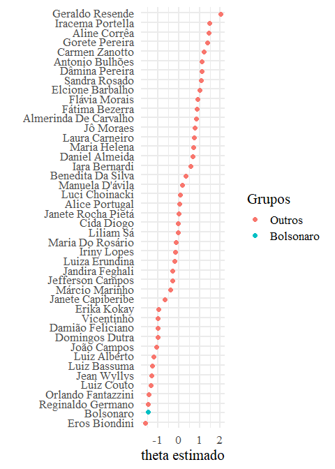

Fonte: Dados Abertos da Câmara dos Deputados

Apesar de Bolsonaro está no extremo inferior, indicando algum nível de radicalismo detectado pelos modelos, Jean Wyllys, que qualitivamente está no extremo oposto no espectro ideológico sobre a pauta, está geometricamente próximo dos Bolsonaro. Numa tentativa de explicação *ad hoc*, é possível sugerir que os modelos estão estimando a saliência do tema nos discursos dos parlamentares, e estão especificando inaquedamente a valência dos posicionamentos.

Figura 2: Análise de Correspondência com discursos de Deputados. Dimensão Liberal x Iliberal. 2001 à 2018.

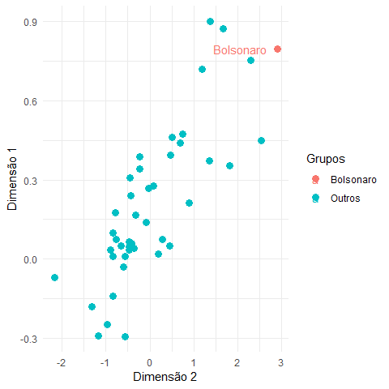

Fonte: Dados Abertos da Câmara dos Deputados

Figura 3: Wordfish com discursos de Bancadas. Dimensão Liberal x Iliberal. 2001 à 2018.

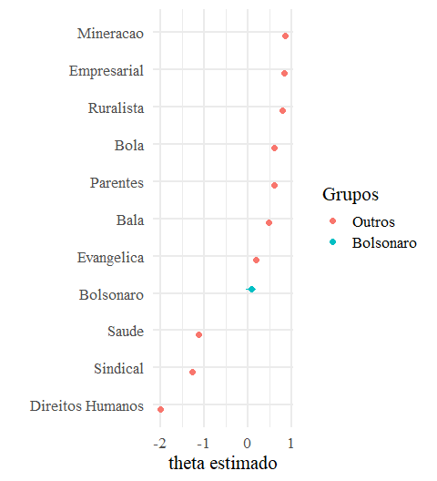

Fonte: Dados Abertos da Câmara dos Deputados

Figura 4: Análise de Correspondência com discursos de Bancadas. Dimensão Liberal x Iliberal. 2001 à 2018.

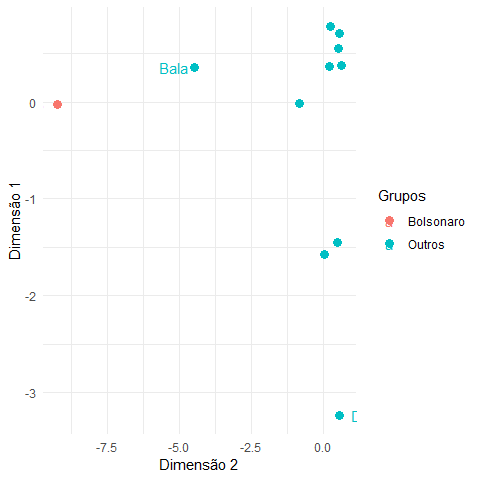

Fonte: Dados Abertos da Câmara dos Deputados

No segundo teste, tomamos a dimensão Anti x Pró-Establishment como norte de análise. Replicando a estratégia anterior, extraímos duas amostras. A primeira conta com `4377` discursos de parlamentares de todas as legislaturas que realizaram ao menos 20 pronunciamentos sobre o tema. A segunda conta com `6138` discursos realizados na legislatura 56 agrupados por bancada.

Como resultado, nos modelos que estimam posicionamento de parlamentares, não é possível observar qualquer congruência nos resultados. Os Bolsonaro aparecem entre Roberto Jefferson e José Eduardo Cardoso, parlamentares os quais, respectivamente, integram o núcleo da oposição da base governista do governo Lula. Somente nas estimativas por bancada foi possível identificar aspectos da polarização entre o Bloco Conservador e o Progressista, apontada por Fagnello (2015, 2017) – conforme as Figuras 7 e 8. Ainda sim, num cenário geral de imprecisão, constituem apenas evidências anedóticas.

Figura 5: Wordfish com discursos de Deputados Dimensão Pró x Anti-Establishment. 2001 à 2018.

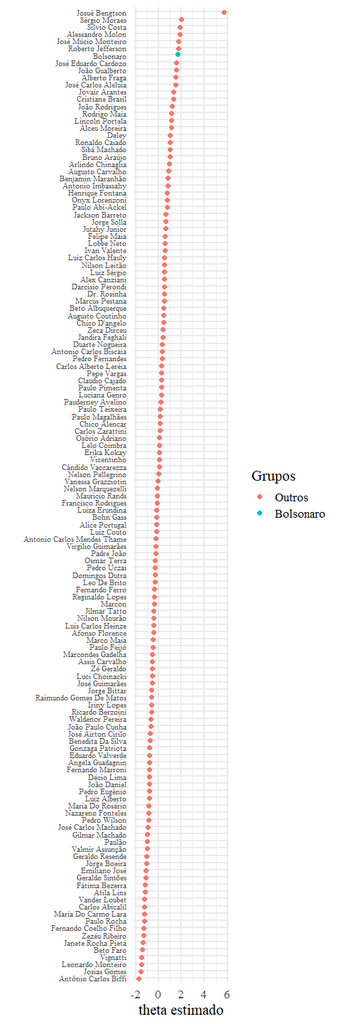

Fonte: Dados Abertos da Câmara dos Deputados

Figura 6: Análise de Correspondência com discursos de Deputados Dimensão Pró x Anti-Establishment. 2001 à 2018.

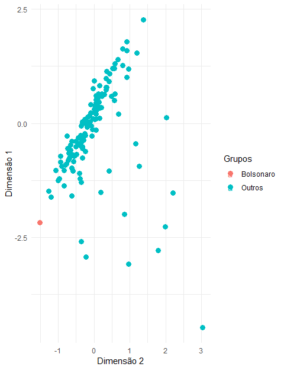

Fonte: Dados Abertos da Câmara dos Deputados

É importante ressaltar, todavia, que possuímos capacidade limitada de acessar a dimensão Pró X Anti-Establishment. Utilizamos palavras-chave com o propósito de capturar discursos que dizem respeito a opiniões expressas sobre o governo e a elite política, porém como a maior parte do período de análise está inserido em governos de lideranças do Partido dos Trabalhadores – 2003 à 2016, na prática, a grande maioria dos discursos diz respeito a opiniões sobre esse grupo político específico.

Figura 7: Wordfish com discursos de Bancadas Dimensão Pró x Anti-Establishment. 2001 à 2018.

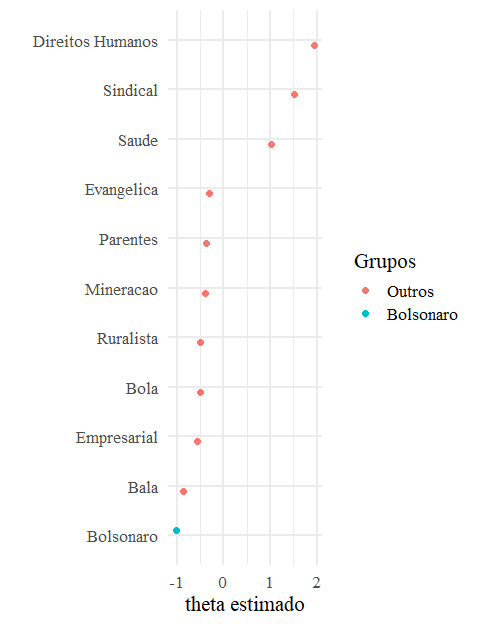

Fonte: Dados Abertos da Câmara dos Deputados

Figura 8: Análise de Correspondência com discursos de Bancadas. Dimensão Pró x Anti-Establishment. 2001 à 2018.

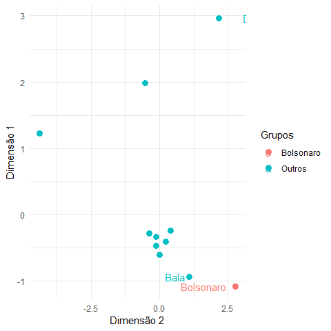

Fonte: Dados Abertos da Câmara dos Deputados

Ainda sim, é possível notar nuances importantes nos resultados. A Bancada Evangélica, apesar de compor um grupo conversador, juntamente com a Bancada da Bala e a Familía Bolsonaro, está distante no que diz a integração ao governo, na medida em que apresenta valores estimados para sua posição na escala da dimensão Pró x Anti-Establishment semelhantes a bancada dos Parentes, a qual apresenta maior propensão a atuação fisiológica.

Como conclusão, podemos afirmar que, observando o posicionamento latente dos parlamentares e das bancadas da Câmara dos Deputados, estimados a partir de técnicas automatizadas de análise de conteúdo, há fortes indícios contrário ao sistema de classificação por categoria de referência, tanto no que diz respeito a dimensão Liberal x Iliberal como na dimensão Pró x Anti-Establishment.

## Discutindo sobre o Resultado das nossas falhas…

A primeira tentativa de operacionalização de um critério de identificação de populistas no Brasil falhou por distanciar método de classificação e definição teórica. O populismo, longe de estar atrelado a um conjunto de personalidades que o personificam, está associado a disposições atitudinais e comportamentais que variam ao longo de uma escala com grandes escalas de cinza.

Declarações que incentivam a violência contra a oposição política, que esteriotipam minorias e rivalizam com as instituições em prol de maiores ponderes presidenciais ou menor poder de veto do Parlamento, apesar de, qualitativamente, serem muito relevantes por seu impacto sobre a democracia e constituírem fortes indícios de populismo Levitsky and Ziblatt (2018); Voeten (2018); Alexander and Welzel (2017), dizem respeito a um universo quantiativamente pequeno de discursos. Ou seja, o populismo é uma característica sutil e latente na atividade parlamentar. O uso de referenciais no critério de classificação por similaridade, nesse caso, inclui grande quantidade de ruído na análise, uma vez que indiossincracias da personalidade dos indivíduos e discursos sobre temas genéricos da atuação política, como regimento, compõem a maior parte dos dados.

Com relação às técnicas utilizadas, *Wordfish* e Análise de Correspondência baseiam-se na premissa de os termos associados a uma tema refletem o escopo do posicionamento de uma parlamentar sobre ele. Isso significa, por exemplo, que discursos sobre economia são permeados de termos como “redistribuição”, “desigualdade social” e “pobreza”, entre aqueles identificado à esquerda do espectro político, e “trabalho”, “desenvolvimento” e “impostos”, entre aqueles à direita. Todavia, *Valence Issues*, como a relação com *establishment* e direitos-humanos e minorias, fogem desse padrão, uma vez que envolvem relações simbólicas entre políticos e valores, as quais não podem ser posicionadas em relação ao espectro esquerda x direita. Nos resultados das estimações dos modelos, pudemos observar que, frequentemente as estimativas de posicionamento latente indistinguiam saliência de polaridade dos discursos.

Como síntese das nossas falhas, inferimos que a modelagem baseada em categoria de referência é bastante sensível a i) indiossincrasias do estilo discursivo do grupo ou elemento de comparação e ii) a frequência da menção a termos. Partindo disso, buscamos solução operacionalizando um novo sistema de classificação e novo arcabouço de técnicas.

## Referências Bibliográficas

Alexander, Amy C, and Christian Welzel. 2017. “The Myth of Deconsolidation: Rising Liberalism and the Populist Reaction.” *Journal of Democracy Web Exchange*.

Altemeyer, Bob, and Robert A Altemeyer. 1996. *The Authoritarian Specter*. Harvard University Press.

Berlatto, Fábia, Adriano Codato, and Bruno Bolognesi. 2016. “Da Polícia à Política: Explicando O Perfil Dos Candidatos Das forças Repressivas de Estado à câmara Dos Deputados.” *Revista Brasileira de Ciência Política*, no. 21: 77–120.

Betz, Hans-George. 1993. “The New Politics of Resentment: Radical Right-Wing Populist Parties in Western Europe.” *Comparative Politics*. JSTOR, 413–27.

Betz, Hans-Georg, and Carol Johnson. 2016. “Against the Current—Stem Ming the Tide: The Nostalgic Ideology of the Contemporary Radical Populist Right.” In *The Populist Radical Right*, 86–100. Routledge.

Cioccari, Deysi, and Simonetta Persichetti. 2018. “Armas, ódio, Medo E Espetáculo Em Jair Bolsonaro.” *Revista Alterjor* 18 (2): 201–14.

Codato, Adriano, Bruno Bolognesi, and Karolina Mattos Roeder. 2015. “A Nova Direita Brasileira: Uma análise Da Dinâmica Partidária E Eleitoral Do Campo Conservador.” *Direita, Volver*, 115–44.

Faganello, Marco Antonio. 2015. “Bancada Da Bala: Uma Onda Na Maré Conservadora.” *Direita, Volver*, 145–61.

———. 2017. “O Voto Na Bancada Da Bala: Estudo de Geografia Eleitoral Na Cidade de São Paulo (2012/2016).” Dissertação de Mestrado.

Foco, Congresso em. 2016. “Conheça as 11 Bancadas Mais Poderosas Da Câmara.” Edited by UOL. https://congressoemfoco.uol.com.br/especial/noticias/conheca-as-11-bancadas-mais-poderosas-da-camara/.

Hunter, Wendy, and Timothy J Power. 2019. “Bolsonaro and Brazil’s Illiberal Backlash.” *Journal of Democracy* 30 (1). Johns Hopkins University Press: 68–82.

Kyle, Jordan, and Limor Gultchin. 2018. “Populists in Power Around the World.” *Tony Blair Institut for Global Change*.

Kyle, Jordan, and Yascha Mounk. 2018. “The Populist Harm to Democracy: An Empirical Assessment.” *Tony Blair Institut for Global Change*.

Levitsky, Steven, and Daniel Ziblatt. 2018. *How Democracies Die*. Crown.

Mudde, Cas. 2010. “The Populist Radical Right: A Pathological Normalcy.” *West European Politics* 33 (6). Taylor & Francis: 1167–86.

———. 2017. “An Ideational Approach.” *The Oxford Handbook of Populism*. Oxford University Press, 27.

Norris, Pippa, and others. 2005. *Radical Right: Voters and Parties in the Electoral Market*. Cambridge University Press.

Penteado, Claudio Luis de Camargo, and Celina Lerner. 2018. “A Direita Na Rede: Mobilização Online No Impeachment de Dilma Rousseff.” Universidade Federal de Minas Gerais.

Slapin, Jonathan B, and Sven-Oliver Proksch. 2008. “A Scaling Model for Estimating Time-Series Party Positions from Texts.” *American Journal of Political Science* 52 (3). Wiley Online Library: 705–22.

Voeten, Erik. 2018. “Populism and Backlashes Against International Courts.” *Available at SSRN 3255764*.

[^1]: Para a 52ª legislatura, conseguimos coletar discursos apenas para os anos de 2001 e 2002.
[^2]: Para a dimensão que mensura os componentes liberais e iliberais do discurso, definimos os termos: ‘natalidade’, ‘lesbicas’, ‘lgbt’, ‘gays’, ‘travestis’, ‘transsexuais’, ‘vasectomia’, ‘humanos’, ‘laqueadura’, ‘trompas’, ‘banheiro’, ‘homossexualismo’, ‘minorias’, ‘negro’, ‘negra’, ‘mulher’, ‘homossexual’, ‘machismo’, ‘feminismo’, ‘racismo’, ‘discriminacao’, ‘feminicidio’, ‘genero’, ‘sexual’, ‘sexuais’, ‘reprodução’ e ‘aborto’. E para dimensão que mensura componentes anti-establishment: ‘fhc’, ‘fernando henrique cardoso’, ‘presidente da republica’, ‘pt’, ‘dilma’, ‘lula’, ‘dirceu’, ‘paloci’, ‘genuino’, ‘mensalao’, ‘petismo’, ‘partido dos trabalhadores’, ‘impeachment’ e ‘temer’.